# Reclassifying Raster Maps in R

### Goals

In this exercise we will  
- learn to interpret raster map values, in this case representing landcover types  
- reclassify raster map values to simplify our landcover categories  
- add labels to map values to make our final map easier to interpret  
- and plot our map on a basemap using the `tmap` package

```r
library(readr)
library(dplyr)
library(terra)
library(tmap)
library(tmaptools)
library(maptiles)
library(OpenStreetMap)
library(osmdata)
library(rJava)
library(xlsx)
```

### Loading and checking the data

We will be working with crop inventory data from Agriculture and Agri-food Canada. We have extracted crop inventory data for 10.5 kn circular buffer around our sampling points near Grande Prairie, Alberta, Canada.  
First let’s import the map and check it’s description

```r
gp2014 <- terra::rast("./data/crop_inventory_2014_GrandePrairie_masked.tif")
gp2014
```

```
## class       : SpatRaster
## dimensions  : 9326, 9332, 1  (nrow, ncol, nlyr)
## resolution  : 30, 30  (x, y)
## extent      : -13226340, -12946380, 7253918, 7533698  (xmin, xmax, ymin, ymax)
## coord. ref. : WGS 84 / Pseudo-Mercator (EPSG:3857)
## source      : crop_inventory_2014_GrandePrairie_masked.tif
## name        : crop_inventory_2014_GrandePrairie_masked
```

Let’s plot the map. Here we see the circular buffers with a radius of 10.5 km where different values represent different landcover types. Many of the buffers overlap, which is why we see some blobs instead of perfect circles, and that’s totally okay.

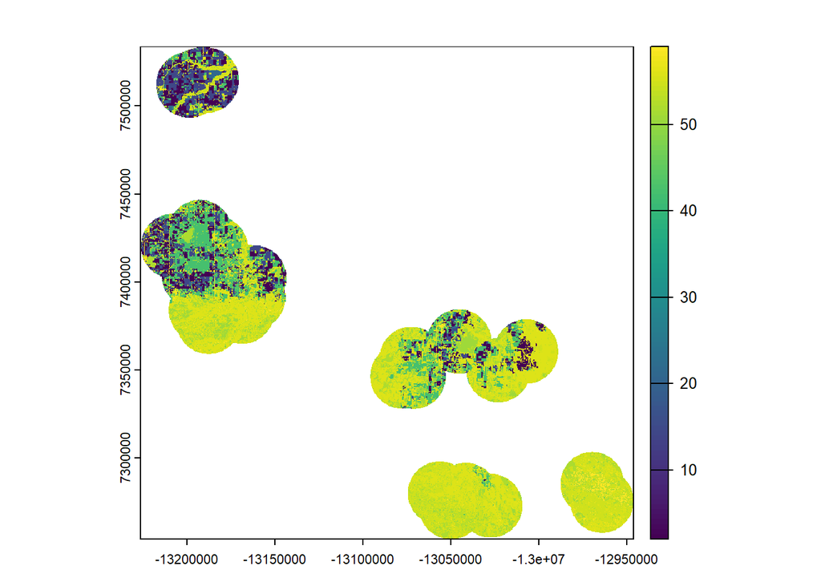

```r
plot(gp2014)
```

Let’s now take a look at the attribute table of this map and find out which values represent which landcover types.

```r
at_gp2014 <- read.csv("./data/attribute_table_crop_inventory_2014_GrandePrairie_masked.csv")
at_gp2014
```

| OID_ | Value | ClassName | Red | Green | Blue | Alpha | Count |
| --- | --- | --- | --- | --- | --- | --- | --- |
| 1 | 2 | Spring wheat | 146 | 165 | 91 | 255 | 1612873 |
| 2 | 3 | Barley | 218 | 227 | 29 | 255 | 88800 |
| 3 | 5 | Oats | 209 | 213 | 43 | 255 | 18795 |
| 4 | 14 | Canola/rapeseed | 214 | 255 | 112 | 255 | 1155911 |
| 5 | 15 | Flaxseed | 140 | 140 | 255 | 255 | 2411 |
| 6 | 21 | Peas | 143 | 108 | 61 | 255 | 177011 |
| 7 | 41 | Grassland | 204 | 204 | 0 | 255 | 6824 |
| 8 | 42 | Pasture/forages | 255 | 204 | 51 | 255 | 2300139 |
| 9 | 48 | Fallow | 255 | 153 | 0 | 255 | 18444 |
| 10 | 49 | Too wet to be seeded | 120 | 153 | 246 | 255 | 1494 |

[output cut: 8 more lines]

This map is what I like to call psuedo-categorical. The “Value” column, which are the values populating the raster, are numerical representations of the categorical “ClassName” column, which indicate the landcover type in a meaningful way.  
Before we go further, let’s make sure that the map doesn’t contain any values that don’t have a match in the attribute table.

```r
unique_values_gp2014 <- unique(values(gp2014))
unique_values_at_gp2014 <- unique(at_gp2014$Value)

print(setdiff( unique_values_gp2014, unique_values_at_gp2014 ))
```

```
## [1] NA
```

```r
print(setdiff( unique_values_at_gp2014, unique_values_gp2014 ))
```

```
## integer(0)
```

```r
# Good, no issues!
```

When we plot the map, it’s a little hard to read as is.  
Let’s associate the ClassName variable in our table, to the values in the raster using the `terra::levels` function.  
To do that, we need to select just the Value and ClassName variables.

```r
landcover_classes <- at_gp2014 %>%
  dplyr::select(Value, ClassName)
```

Now let’s check to see if there are any levels already in the map.

```r
levels(gp2014)
```

```
## [[1]]
## [1] ""
```

```r
# Nope. Good, didn't think so!
```

### Adding labels

Now, let’s make a copy of our map and add our ClassNames to it.

```r
gp2014_named <- gp2014
levels(gp2014_named) <- landcover_classes
```

Let’s check the changes . . .

```r
levels(gp2014_named)
```

```
## [[1]]
##    Value            ClassName
## 1      2         Spring wheat
## 2      3               Barley
## 3      5                 Oats
## 4     14      Canola/rapeseed
## 5     15             Flaxseed
## 6     21                 Peas
## 7     41            Grassland
## 8     42      Pasture/forages
## 9     48               Fallow
## 10    49 Too wet to be seeded
## 11    51              Wetland
## 12    52                Water
## 13    53            Shrubland
## 14    55           Coniferous
## 15    56            Broadleaf
## 16    57            Mixedwood
## 17    58      Urban/developed
## 18    59  Exposed land/barren
```

```r
gp2014_named
```

```
## class       : SpatRaster
## dimensions  : 9326, 9332, 1  (nrow, ncol, nlyr)
## resolution  : 30, 30  (x, y)
## extent      : -13226340, -12946380, 7253918, 7533698  (xmin, xmax, ymin, ymax)
## coord. ref. : WGS 84 / Pseudo-Mercator (EPSG:3857)
## source      : crop_inventory_2014_GrandePrairie_masked.tif
## categories  : ClassName
## name        : ClassName
## min value   :        NA
## max value   :        NA
```

Now when we plot the map, we see the ClassNames instead of the values they represent.

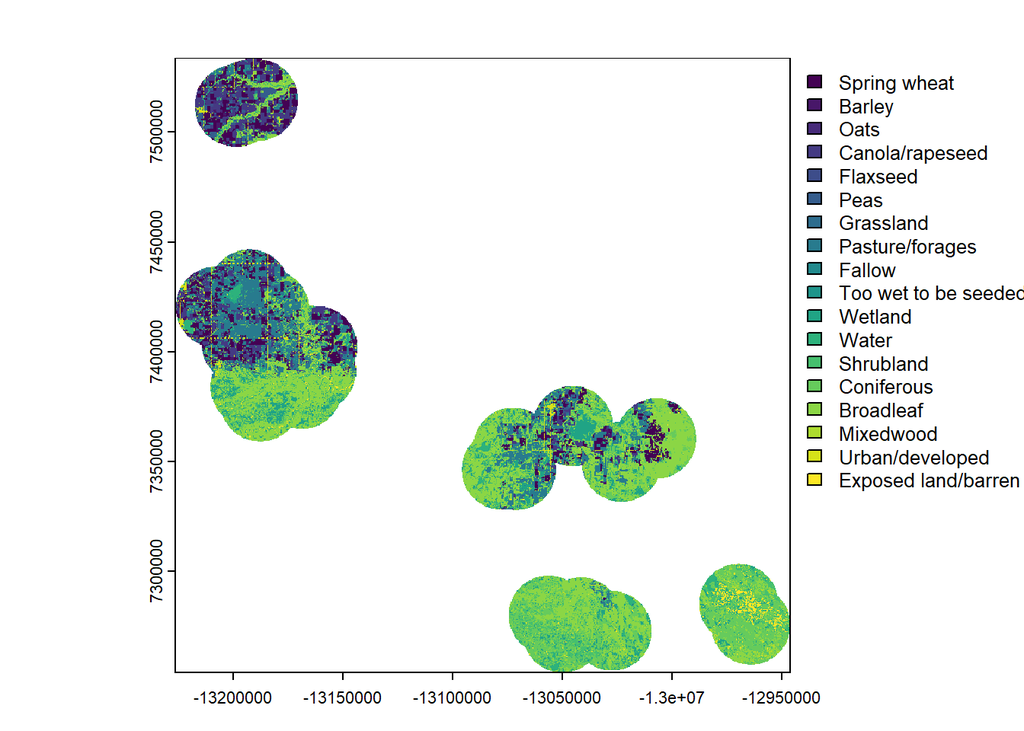

```r
plot(gp2014_named)
```

### Reclassification

Now we can start the reclassification process.  
First we need to determine what we want to reclassify.  
We have 18 landcover types that we want to simplify into 9 as follows.

Reclassification of Landcover Types

| new_class | new_value | old_class |
| --- | --- | --- |
| Grassland | 100 | Grassland, shurubland, pasture/forages |
| Forest | 101 | Broadleaf, mixedwood, coniferous |
| Barren | 102 | Exposed land/barren, fallow, too wet to be seeded |
| Non-flowering Crop | 103 | Spring wheat, barley, oats, flaxseed |
| Canola | NA | Canola/rapeseed |
| Flowering Crop | NA | Peas |
| Wetland | NA | Wetland |
| Water | NA | Water |
| Developed | NA | Developed/urban |

We only need to make changes to the first 4 categories, the rest can stay as is.  
First we need to make reclassification tables that indicate which values are getting converted to which. In the table below, values 41, 42, and 53 represent grassland, pasture/forages, and shrubland. We will be setting all of these values to 100.

```r
grass_rc <- data.frame(from =c(41,42, 53), to =100)
grass_rc
```

| from | to |
| --- | --- |
| 41 | 100 |
| 42 | 100 |
| 53 | 100 |

Now we can test the classify function. Let’s save our re-classified map to a different object name and plot it. If we re-classified the named version of our map, terra would automatically erase the ClassNames and create some problems for us, so we use the unnamed map.

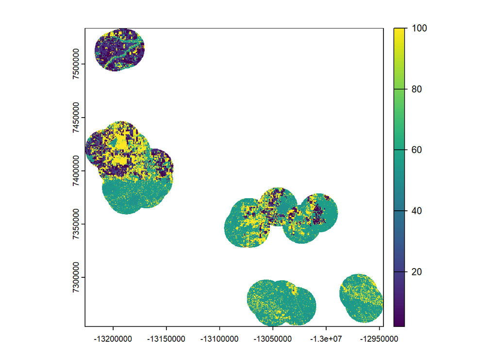

```r
gp2014_b <- terra::classify(gp2014, grass_rc)
plot(gp2014_b)
```

Now that we know how classify works, we can go ahead and do all of our reclassifications at once, then add the approriate ClassNames to the reclassified map.  
Let’s make the rest of our reclassification tables

```r
forest_rc <- data.frame(from=c(55,56,57), to = 101)
barren_rc <- data.frame(from=c(59,48,49), to = 102)
nonflower_rc <- data.frame(from=c(2,3,5,15), to = 103)

rc_list <- list(grass_rc, forest_rc, barren_rc, nonflower_rc)

rc_data <- dplyr::bind_rows(rc_list)
rc_data
```

| from | to |
| --- | --- |
| 41 | 100 |
| 42 | 100 |
| 53 | 100 |
| 55 | 101 |
| 56 | 101 |
| 57 | 101 |
| 59 | 102 |
| 48 | 102 |
| 49 | 102 |
| 2 | 103 |

[output cut: 3 more lines]

Now let’s reclassify everything

```r
gp2014_rc <- terra::classify(gp2014, rc_data)
gp2014
```

```
## class       : SpatRaster
## dimensions  : 9326, 9332, 1  (nrow, ncol, nlyr)
## resolution  : 30, 30  (x, y)
## extent      : -13226340, -12946380, 7253918, 7533698  (xmin, xmax, ymin, ymax)
## coord. ref. : WGS 84 / Pseudo-Mercator (EPSG:3857)
## source      : crop_inventory_2014_GrandePrairie_masked.tif
## name        : crop_inventory_2014_GrandePrairie_masked
```

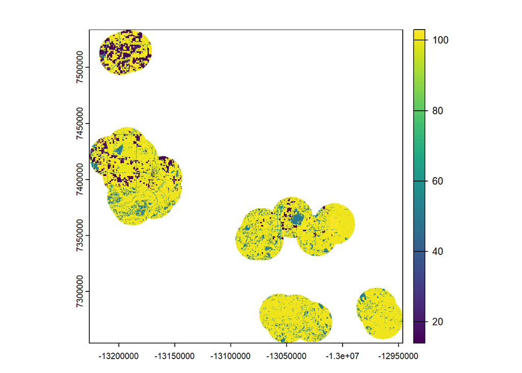

```r
plot(gp2014_rc)
```

```r
unique_values_gp2014_rc <- unique(values(gp2014_rc))
unique_values_gp2014_rc
```

```
##       crop_inventory_2014_GrandePrairie_masked
##  [1,]                                      NaN
##  [2,]                                       14
##  [3,]                                       58
##  [4,]                                      103
##  [5,]                                      101
##  [6,]                                       51
##  [7,]                                      100
##  [8,]                                      102
##  [9,]                                       52
## [10,]                                       21
```

Now we can create our new labels

```r
new_landcover_names <- data.frame(values = unique_values_gp2014_rc[-1], Landcover = c("Canola", "Developed", "Non-Flowering_Crop", "Forest", "Wetland", "Grassland", "Barren", "Water", "Flowering_Crop"))
new_landcover_names
```

| values | Landcover |
| --- | --- |
| 14 | Canola |
| 58 | Developed |
| 103 | Non-Flowering_Crop |
| 101 | Forest |
| 51 | Wetland |
| 100 | Grassland |
| 102 | Barren |
| 52 | Water |
| 21 | Flowering_Crop |

and set them to our reclassified map

```r
levels(gp2014_rc)<- new_landcover_names
levels(gp2014_rc)
```

```
## [[1]]
##   values          Landcover
## 1     14             Canola
## 2     58          Developed
## 3    103 Non-Flowering_Crop
## 4    101             Forest
## 5     51            Wetland
## 6    100          Grassland
## 7    102             Barren
## 8     52              Water
## 9     21     Flowering_Crop
```

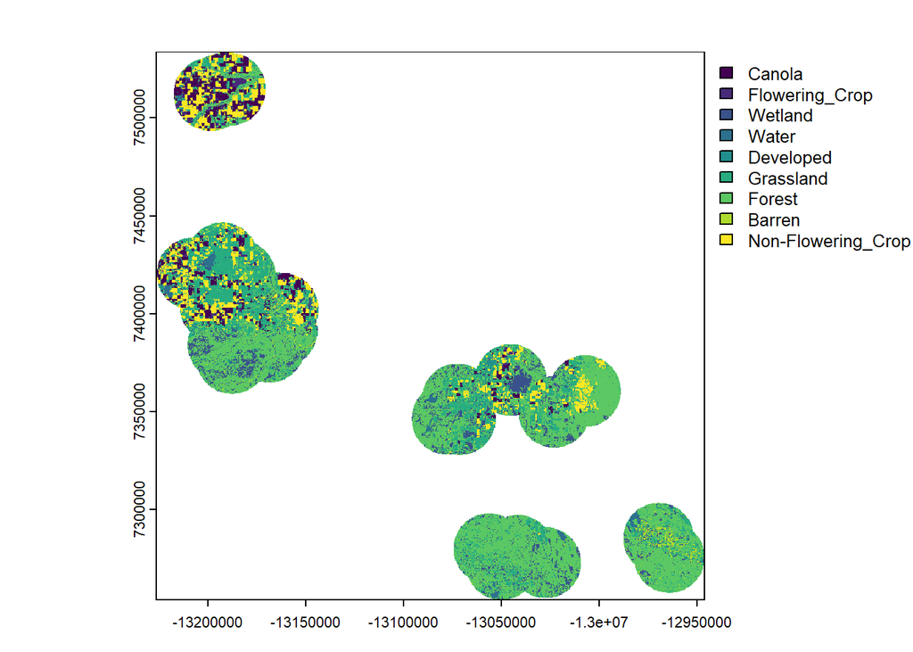

```r
plot(gp2014_rc)
```

Let’s quickly make the map in tmap

```r
tmap_mode("view")
```

```
## ℹ tmap mode set to "view".
```

```r
final_map <-
  tm_shape(gp2014_rc) + tm_raster(palette=c("gold3", "grey55","tan4", "olivedrab","lightskyblue3",  "darkolivegreen2","darkred", "darkblue","lightpink2"))+
  tm_layout(legend.frame = FALSE)+
  #tm_compass(position = c("left", "bottom"))+
  tm_scale_bar(position = c("left", "bottom"))+
  tm_basemap(leaflet::providers$Stadia.Outdoors) # add a basemap so we can see what's around our points more easily
```

```
##
## ── tmap v3 code detected ───────────────────────────────────────────────────────
## [v3->v4] `tm_tm_raster()`: migrate the argument(s) related to the scale of the
## visual variable `col` namely 'palette' (rename to 'values') to col.scale =
## tm_scale(<HERE>).! `tm_scale_bar()` is deprecated. Please use `tm_scalebar()` instead.
```

```r
final_map
```

```
## SpatRaster object downsampled to 3162 by 3164 cells.
```

[interactive chart not shown]